# ABI_Final_Project

#### Report on Causes of Heart Disease based on given columns:

#### Heart Disease:

Coronary illness depicts a scope of conditions that influence your heart. Ailments under the coronary illness umbrella incorporate vein maladies, for example, coronary supply route ailment; heart cadence issues (arrhythmias); and heart absconds you're brought into the world with (inborn heart surrenders), among others.

The expression "coronary illness" is regularly utilized conversely with the expression "cardiovascular infection." Cardiovascular sickness for the most part alludes to conditions that include limited or blocked veins that can prompt a respiratory failure, chest torment (angina) or stroke. Other heart conditions, for example, those that influence your heart's muscle, valves or musicality, likewise are viewed as types of coronary illness.

Numerous types of coronary illness can be anticipated or treated with solid way of life decisions.

#### Data Reading and Cleaning:

```python
import numpy as np
import pandas as pd
import matplotlib.pyplot as plt
import seaborn as sns
import warnings
warnings.filterwarnings('ignore')
color=sns.color_palette()
```

```python
data=pd.read_csv(r"E:\USA\University\Rutgers\Course\ABI\heart.csv")
```

```python
data.head()
```

|  | age | sex | cp | trestbps | chol | fbs | restecg | thalach | exang | oldpeak | slope | ca | thal | target |
| --- | --- | --- | --- | --- | --- | --- | --- | --- | --- | --- | --- | --- | --- | --- |
| 0 | 63 | 1 | 3 | 145 | 233 | 1 | 0 | 150 | 0 | 2.3 | 0 | 0 | 1 | 1 |
| 1 | 37 | 1 | 2 | 130 | 250 | 0 | 1 | 187 | 0 | 3.5 | 0 | 0 | 2 | 1 |
| 2 | 41 | 0 | 1 | 130 | 204 | 0 | 0 | 172 | 0 | 1.4 | 2 | 0 | 2 | 1 |
| 3 | 56 | 1 | 1 | 120 | 236 | 0 | 1 | 178 | 0 | 0.8 | 2 | 0 | 2 | 1 |
| 4 | 57 | 0 | 0 | 120 | 354 | 0 | 1 | 163 | 1 | 0.6 | 2 | 0 | 2 | 1 |

```python
data.info()
```

```
<class 'pandas.core.frame.DataFrame'>
RangeIndex: 303 entries, 0 to 302
Data columns (total 14 columns):
age         303 non-null int64
sex         303 non-null int64
cp          303 non-null int64
trestbps    303 non-null int64
chol        303 non-null int64
fbs         303 non-null int64
restecg     303 non-null int64
thalach     303 non-null int64
exang       303 non-null int64
oldpeak     303 non-null float64
slope       303 non-null int64
ca          303 non-null int64
thal        303 non-null int64
target      303 non-null int64
dtypes: float64(1), int64(13)
memory usage: 33.2 KB
```

```python
data.tail()
```

|  | age | sex | cp | trestbps | chol | fbs | restecg | thalach | exang | oldpeak | slope | ca | thal | target |
| --- | --- | --- | --- | --- | --- | --- | --- | --- | --- | --- | --- | --- | --- | --- |
| 298 | 57 | 0 | 0 | 140 | 241 | 0 | 1 | 123 | 1 | 0.2 | 1 | 0 | 3 | 0 |
| 299 | 45 | 1 | 3 | 110 | 264 | 0 | 1 | 132 | 0 | 1.2 | 1 | 0 | 3 | 0 |
| 300 | 68 | 1 | 0 | 144 | 193 | 1 | 1 | 141 | 0 | 3.4 | 1 | 2 | 3 | 0 |
| 301 | 57 | 1 | 0 | 130 | 131 | 0 | 1 | 115 | 1 | 1.2 | 1 | 1 | 3 | 0 |
| 302 | 57 | 0 | 1 | 130 | 236 | 0 | 0 | 174 | 0 | 0.0 | 1 | 1 | 2 | 0 |

```python
#To find if there are any missing values or null values.
data.isnull().sum()
```

```
age         0
sex         0
cp          0
trestbps    0
chol        0
fbs         0
restecg     0
thalach     0
exang       0
oldpeak     0
slope       0
ca          0
thal        0
target      0
dtype: int64
```

Good to see there are no missing values.

```python
data.shape
```

```
(303, 14)
```

```python
data.describe()
```

|  | age | sex | cp | trestbps | chol | fbs | restecg | thalach | exang | oldpeak | slope | ca | thal | target |
| --- | --- | --- | --- | --- | --- | --- | --- | --- | --- | --- | --- | --- | --- | --- |
| count | 303.000000 | 303.000000 | 303.000000 | 303.000000 | 303.000000 | 303.000000 | 303.000000 | 303.000000 | 303.000000 | 303.000000 | 303.000000 | 303.000000 | 303.000000 | 303.000000 |
| mean | 54.366337 | 0.683168 | 0.966997 | 131.623762 | 246.264026 | 0.148515 | 0.528053 | 149.646865 | 0.326733 | 1.039604 | 1.399340 | 0.729373 | 2.313531 | 0.544554 |
| std | 9.082101 | 0.466011 | 1.032052 | 17.538143 | 51.830751 | 0.356198 | 0.525860 | 22.905161 | 0.469794 | 1.161075 | 0.616226 | 1.022606 | 0.612277 | 0.498835 |
| min | 29.000000 | 0.000000 | 0.000000 | 94.000000 | 126.000000 | 0.000000 | 0.000000 | 71.000000 | 0.000000 | 0.000000 | 0.000000 | 0.000000 | 0.000000 | 0.000000 |
| 25% | 47.500000 | 0.000000 | 0.000000 | 120.000000 | 211.000000 | 0.000000 | 0.000000 | 133.500000 | 0.000000 | 0.000000 | 1.000000 | 0.000000 | 2.000000 | 0.000000 |
| 50% | 55.000000 | 1.000000 | 1.000000 | 130.000000 | 240.000000 | 0.000000 | 1.000000 | 153.000000 | 0.000000 | 0.800000 | 1.000000 | 0.000000 | 2.000000 | 1.000000 |
| 75% | 61.000000 | 1.000000 | 2.000000 | 140.000000 | 274.500000 | 0.000000 | 1.000000 | 166.000000 | 1.000000 | 1.600000 | 2.000000 | 1.000000 | 3.000000 | 1.000000 |
| max | 77.000000 | 1.000000 | 3.000000 | 200.000000 | 564.000000 | 1.000000 | 2.000000 | 202.000000 | 1.000000 | 6.200000 | 2.000000 | 4.000000 | 3.000000 | 1.000000 |

#### Column Description:

Age: The individual's age in years

Sex: The individual's sex (1 = male, 0 = female)

Cp: The chest torment experienced (Value 1: run of the mill angina, Value 2: atypical angina, Value 3: non-anginal agony, Value asymptomatic)

Trestbps: The individual's resting pulse (mm Hg on admission to the clinic)

Chol: The individual's cholesterol estimation in mg/dl

Fbs: The individual's fasting glucose (> 120 mg/dl, 1 = genuine; 0 = bogus)

Restecg: Resting electrocardiographic estimation (0 = typical, 1 = having ST-T wave variation from the norm, 2 = indicating likely or distinct left ventricular hypertrophy by Estes' criteria)

Thalach: The individual's greatest pulse accomplished

Exang: Exercise prompted angina (1 = yes; 0 = no)

Oldpeak: ST misery actuated by practice comparative with rest ('ST' identifies with positions on the ECG plot. See progressively here)

Target: Heart infection (0 = no, 1 = yes)

#### Exploratory Data Analysis and Visualization:

##### Lets first plot sex category to comprehend the sufferings from heart disease.

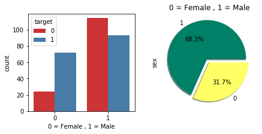

```python
fig,ax=plt.subplots(1,2,figsize=(7,3))
sns.countplot(x='sex',data = data, hue='target',palette='Set1',ax=ax[0])
ax[0].set_xlabel("0 = Female , 1 = Male")
data.sex.value_counts().plot.pie(ax=ax[1],autopct='%1.1f%%',shadow=True, explode=[0.1,0], cmap = 'summer')
ax[1].set_title("0 = Female , 1 = Male")
plt.show()
```

##### Plot the similar graph for cause of Heart Disease due to Fasting Blood Sugar (FBS)

A blood sample will be taken after an overnight fast. A fasting blood sugar level less than 100 mg/dL (5.6 mmol/L) is normal. A fasting blood sugar level from 100 to 125 mg/dL (5.6 to 6.9 mmol/L) is considered prediabetes. If it's 126 mg/dL (7 mmol/L) or higher on two separate tests, you have diabetes.

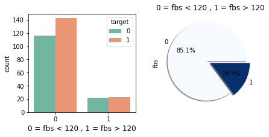

```python
fig,ax=plt.subplots(1,2,figsize=(7,3))
sns.countplot(x='fbs',data=data,hue='target',palette='Set2',ax=ax[0])
ax[0].set_xlabel("0 = fbs < 120 , 1 = fbs > 120", size=12)
data.fbs.value_counts().plot.pie(ax=ax[1],autopct='%1.1f%%',shadow=True, explode=[0.1,0],cmap='Blues')
ax[1].set_title("0 = fbs < 120 , 1 = fbs > 120", size=12)
plt.show()
```

##### Analysing the target and ECG to find the sufferings of Heart Disease.

An electrocardiogram (ECG) is a test which quantifies the electrical movement of your heart to show whether it is working ordinarily. An ECG records the heart's mood and action on a moving piece of paper or a line on a screen.

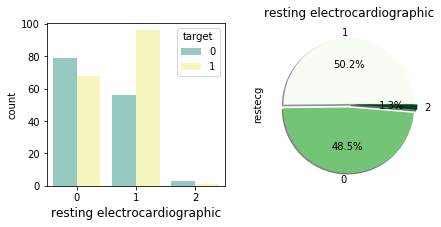

```python
fig,ax=plt.subplots(1,2,figsize=(7,3))
sns.countplot(x='restecg',data=data,hue='target',palette='Set3',ax=ax[0])
ax[0].set_xlabel("resting electrocardiographic",size=12)
data.restecg.value_counts().plot.pie(ax=ax[1],autopct='%1.1f%%',shadow=True,
                                     explode=[0.005,0.05,0.05],cmap='Greens')
ax[1].set_title("resting electrocardiographic",size=12)

plt.show()
```

From the above graph we can understand that ECG = 1 will lead to person causing higher chance of Heart Disease.

##### Comparing the ST segment and target and comprehending the data.

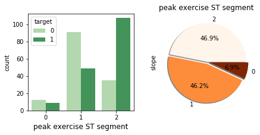

```python
fig,ax=plt.subplots(1,2,figsize=(7,3))
sns.countplot(x='slope',data=data,hue='target',palette='Greens',ax=ax[0])
ax[0].set_xlabel("peak exercise ST segment",size=12)
data.slope.value_counts().plot.pie(ax=ax[1],autopct='%1.1f%%',shadow=True,explode=[0.005,0.05,0.05],cmap='Oranges')

ax[1].set_title("peak exercise ST segment ",size=12)
plt.show()
```

The above graph explains that Individuals having up slanting are more inclined to Heart Disease than level and downsloping. slope consist of three types where flat, up sloping and downsloping.

##### To analyse people died due to chest pain type.

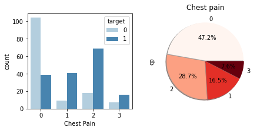

```python
fig,ax=plt.subplots(1,2,figsize=(7,3))
sns.countplot(x='cp',data=data,hue='target',palette='Blues',ax=ax[0])
ax[0].set_xlabel("Chest Pain")
data.cp.value_counts().plot.pie(ax=ax[1],autopct='%1.1f%%',explode=[0.01,0.01,0.01,0.01],shadow=True, cmap='Reds')
ax[1].set_title("Chest pain")
plt.show()
```

From above graph we can say that the bar graph of the chest pain is given 4 levels where we can see majority of people got targeted after level 2 of chest pain.

#### Continuous Feature

All out factors contain a limited number of classes or unmistakable gatherings. Unmitigated information probably won't have a legitimate request. Ceaseless factors are numeric factors that have a limitless number of qualities between any two qualities. A constant variable can be numeric or date/time.

##### Trestbps

We will compare the trestbps with Gender, Chest Pain, Exang and Major Vessels inorder to plot the graphs and prognosis the basic understanding of causes of Heart Disease.

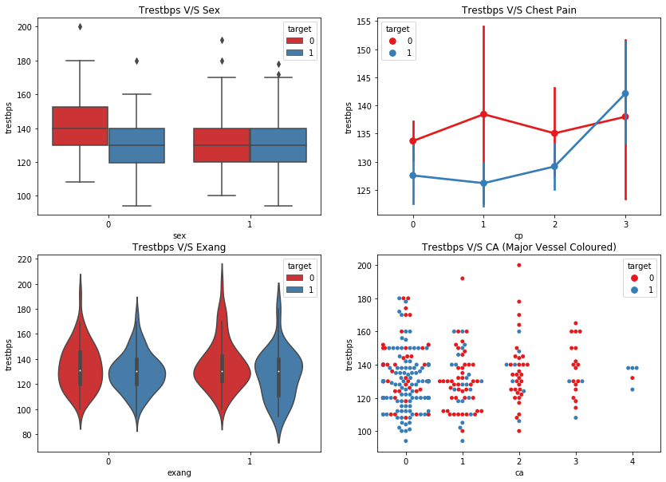

[figure not shown]

```python
fig,ax=plt.subplots(2,2,figsize=(14,10))
sns.boxplot(y='trestbps',data=data,x='sex',hue='target',palette='Set1',ax=ax[0,0])
ax[0,0].set_title("Trestbps V/S Sex")
sns.factorplot(y='trestbps',data=data,x='cp',hue='target',ax=ax[0,1],palette='Set1')
ax[0,1].set_title("Trestbps V/S Chest Pain")
sns.violinplot(y='trestbps',data=data,x='exang',hue='target',ax=ax[1,0],palette='Set1')
ax[1,0].set_title("Trestbps V/S Exang")
sns.swarmplot(y='trestbps',data=data,x='ca',hue='target',ax=ax[1,1],palette='Set1')
ax[1,1].set_title("Trestbps V/S CA (Major Vessel Coloured)")
plt.show()
```

In light of the above examination, we can say that Gender assumes a minor job as for Blood Pressure (trestbps). Yet, Chest Pain assumes Vital Role. As Chest torment builds Blood Pressure will likewise increment alongside odds of Heart Diseases.

##### Similary we will plot for Cholestrol as well.

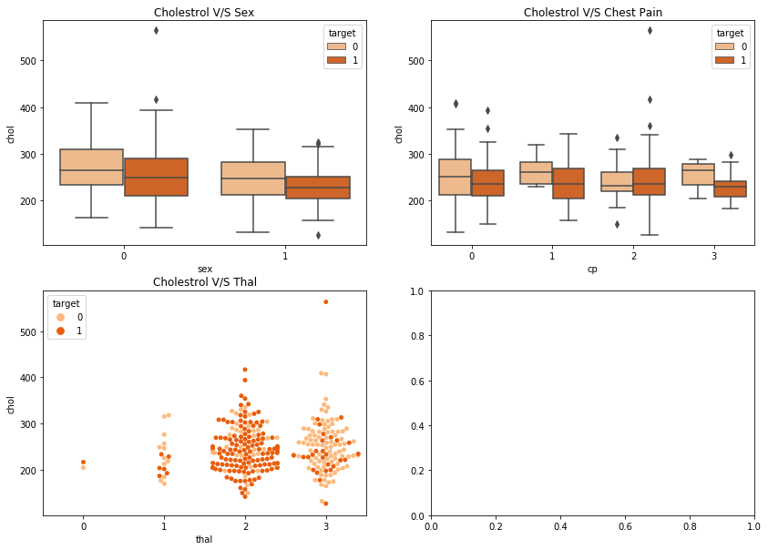

```python
fig,ax=plt.subplots(2,2,figsize=(14,10))
sns.boxplot(y='chol',data=data,x='sex',hue='target',palette='Oranges',ax=ax[0,0])
ax[0,0].set_title("Cholestrol V/S Sex")
sns.boxplot(y='chol',data=data,x='cp',hue='target',ax=ax[0,1],palette='Oranges')
ax[0,1].set_title("Cholestrol V/S Chest Pain")
sns.swarmplot(y='chol',data=data,x='thal',hue='target',ax=ax[1,0],palette='Oranges')
ax[1,0].set_title("Cholestrol V/S Thal")

plt.show()
```

##### Comparing OldPeak with other category

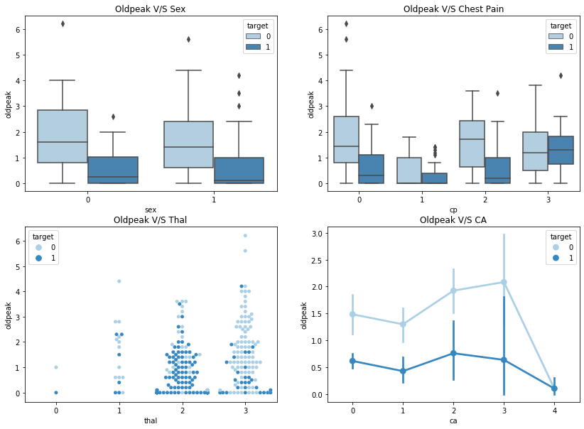

[figure not shown]

```python
fig,ax=plt.subplots(2,2,figsize=(14,10))
sns.boxplot(y='oldpeak',data=data,x='sex',hue='target',palette='Blues',ax=ax[0,0])
ax[0,0].set_title("Oldpeak V/S Sex")
sns.boxplot(y='oldpeak',data=data,x='cp',hue='target',ax=ax[0,1],palette='Blues')
ax[0,1].set_title("Oldpeak V/S Chest Pain")
sns.swarmplot(y='oldpeak',data=data,x='thal',hue='target',ax=ax[1,0],palette='Blues')
ax[1,0].set_title("Oldpeak V/S Thal")
sns.factorplot(y='oldpeak',data=data,x='ca',hue='target',ax=ax[1,1],palette='Blues')
ax[1,1].set_title("Oldpeak V/S CA")

plt.show()
```

Classification of Oldpeak is given as:

Less than 2 is considered as low

Anything that range between 1.5 - 3.5 will lead to risk

And, anything above 3 is terrible.

From the above plot we can say, on the off chance that Oldpeak is less, at that point individuals will have more odds of having heart maladies.

#### Plotting Histogram of given feature.

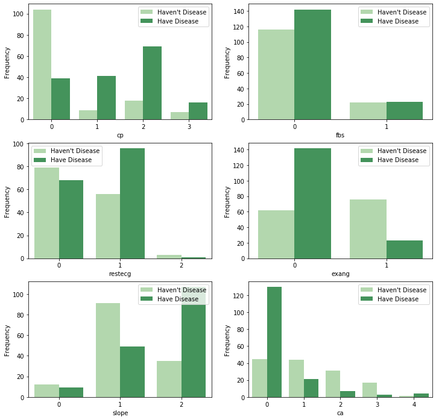

```python
fig, axes = plt.subplots(3, 2, figsize=(12,12))
fs = ['cp', 'fbs', 'restecg','exang', 'slope', 'ca']
for i, axi in enumerate(axes.flat):
    sns.countplot(x=fs[i], hue='target', data=data, palette='Greens', ax=axi)
    axi.set(ylabel='Frequency')
    axi.legend(["Haven't Disease", "Have Disease"])
plt.show()
```

#### Density plot with respect to Mean and Standard Deviation.

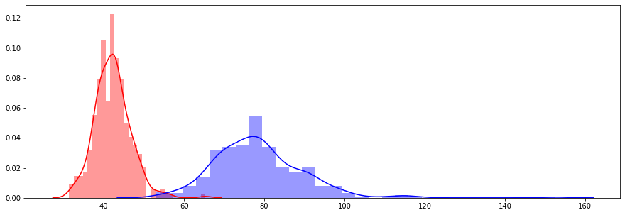

```python
fig,ax=plt.subplots(1,1,figsize=(15,5))
features = data.columns
sns.distplot(data[features].mean(axis=1),kde=True,bins=30,color='red')
sns.distplot(data[features].std(axis=1),kde=True,bins=30,color='blue')
plt.show()
```

#### Heatmap plotting:

The heatmap is a method for speaking to the information in a 2-dimensional structure. The information esteems are spoken to as hues in the chart. The objective of the heatmap is to give a shaded visual rundown of data

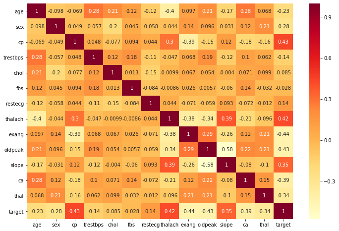

```python
plt.figure(figsize=(12,8))
sns.heatmap(data.corr(),annot=True,cmap = 'YlOrRd')
plt.show()
```

#### Feature Transformation

It is utilized to cast a pandas item to a predefined dtype. astype() work additionally gives the capacity to change over any appropriate existing section to categorical type. DataFrame.astype() work comes helpful when we need to case a specific section data type to another data type.

```python
data.sex=data.sex.astype('category')
data.cp=data.cp.astype('category')
data.fbs=data.fbs.astype('category')
data.restecg=data.restecg.astype('category')
data.exang=data.exang.astype('category')
data.ca=data.ca.astype('category')
data.slope=data.slope.astype('category')
data.thal=data.thal.astype('category')
```

```python
X = data.drop(['target'], axis = 1)
y = data.target.values
```

#### Creating Dummy Variables

```python
chest_pain=pd.get_dummies(data['cp'],prefix='cp',drop_first=True)
data=pd.concat([data,chest_pain],axis=1)
data.drop(['cp'],axis=1,inplace=True)
sp=pd.get_dummies(data['slope'],prefix='slope')
th=pd.get_dummies(data['thal'],prefix='thal')
frames=[data,sp,th]
data=pd.concat(frames,axis=1)
data.drop(['slope','thal'],axis=1,inplace=True)
```

```python
data.head()
```

|  | age | sex | trestbps | chol | fbs | restecg | thalach | exang | oldpeak | ca | ... | cp_1 | cp_2 | cp_3 | slope_0 | slope_1 | slope_2 | thal_0 | thal_1 | thal_2 | thal_3 |
| --- | --- | --- | --- | --- | --- | --- | --- | --- | --- | --- | --- | --- | --- | --- | --- | --- | --- | --- | --- | --- | --- |
| 0 | 63 | 1 | 145 | 233 | 1 | 0 | 150 | 0 | 2.3 | 0 | ... | 0 | 0 | 1 | 1 | 0 | 0 | 0 | 1 | 0 | 0 |
| 1 | 37 | 1 | 130 | 250 | 0 | 1 | 187 | 0 | 3.5 | 0 | ... | 0 | 1 | 0 | 1 | 0 | 0 | 0 | 0 | 1 | 0 |
| 2 | 41 | 0 | 130 | 204 | 0 | 0 | 172 | 0 | 1.4 | 0 | ... | 1 | 0 | 0 | 0 | 0 | 1 | 0 | 0 | 1 | 0 |
| 3 | 56 | 1 | 120 | 236 | 0 | 1 | 178 | 0 | 0.8 | 0 | ... | 1 | 0 | 0 | 0 | 0 | 1 | 0 | 0 | 1 | 0 |
| 4 | 57 | 0 | 120 | 354 | 0 | 1 | 163 | 1 | 0.6 | 0 | ... | 0 | 0 | 0 | 0 | 0 | 1 | 0 | 0 | 1 | 0 |

5 rows × 21 columns

Pandas has a capacity which can transform an absolute variable into a progression of zeros and ones, which makes them significantly simpler to evaluate and analyze.

```python
X = data.drop(['target'], axis = 1)
y = data.target.values
```

#### Implementation of Predictive Models

##### Splitting the dataset into training and test set

The dataset we use is typically part of training data and test data. The training set contains a known yield and the model learns on this data so as to be summed up to other information later on. We have the test dataset (or subset) so as to test our model's expectation on this subset.

```python
from sklearn.model_selection import train_test_split
X_train, X_test, y_train, y_test = train_test_split(X, y, test_size = 0.2, random_state=0)
```

#### Preprocessing of Data by standardizing the scalar value of features

```python
from sklearn.preprocessing import StandardScaler
sc_X=StandardScaler()
X_train=sc_X.fit_transform(X_train)
X_test=sc_X.transform(X_test)
```

It changes the information in such a way, that it has mean as 0 and standard deviation as 1. To put it plainly, it standardizes the information. Institutionalization is helpful for information which has negative qualities. It masterminds the information in typical circulation.

#### Evaluation of the model using Cross Validator

```python
from sklearn.linear_model import LogisticRegression
from sklearn.ensemble import RandomForestClassifier
from sklearn.metrics import average_precision_score
from sklearn.model_selection import cross_val_score
from sklearn.metrics import precision_recall_curve
from sklearn.neighbors import KNeighborsClassifier
from sklearn.tree import DecisionTreeClassifier
from sklearn.metrics import confusion_matrix
from sklearn.metrics import accuracy_score
from sklearn.naive_bayes import GaussianNB
from sklearn.metrics import roc_curve
from sklearn.metrics import f1_score
from sklearn.metrics import auc
from sklearn.svm import SVC
%matplotlib inline
```

#### Implementing ML algorthims:

Each AI calculation works best under a given arrangement of conditions. Ensuring your calculation fits the presumptions/prerequisites guarantees unrivaled execution. You can't utilize any calculation in any condition. For e.g.: We can't utilize straight relapse on a categorical dependent variable. Since we won't be acknowledged for getting incredibly low estimations of balanced R² and F measurement. Rather, in such circumstances, we should take a stab at utilizing calculations, for example, Logistic Regression, Decision Trees, Support Vector Machine (SVM), Random Forest, and so on.

#### Logistic Regression

Logistic regression is a measurable model that in its fundamental structure utilizes a calculated capacity to demonstrate a parallel ward variable, albeit a lot increasingly complex expansions exist. In regression examination, strategic relapse (or logit relapse) is assessing the parameters of a calculated model (a type of twofold relapse).

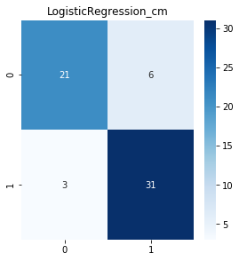

```python
#LogisticRegression
lr_c=LogisticRegression(random_state=0)
lr_c.fit(X_train,y_train)
lr_pred=lr_c.predict(X_test)
lr_cm=confusion_matrix(y_test,lr_pred)
lr_ac=accuracy_score(y_test, lr_pred)
plt.figure(figsize=(20,10))
plt.subplot(2,4,1)
plt.title("LogisticRegression_cm")
sns.heatmap(lr_cm,annot=True,cmap="Blues",fmt="d",cbar=True)
plt.show()
```

#### Naive's Bayes Classifier

Naive's Bayes is a straightforward, yet compelling and regularly utilized, AI classifier. It is a probabilistic classifier that makes groupings utilizing the Maximum A Posteriori choice standard in a Bayesian setting. It can likewise be spoken to utilizing a straightforward Bayesian system. Naive's Bayes classifiers have been particularly prominent for content order, and are a conventional answer for issues, for example, spam recognition.

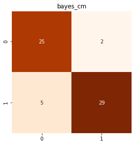

```python
#Bayes
gaussian=GaussianNB()
gaussian.fit(X_train,y_train)
bayes_pred=gaussian.predict(X_test)
bayes_cm=confusion_matrix(y_test,bayes_pred)
bayes_ac=accuracy_score(bayes_pred,y_test)

plt.figure(figsize=(20,10))
plt.subplot(2,4,3)
plt.title("bayes_cm")
sns.heatmap(bayes_cm,annot=True,cmap="Oranges",fmt="d",cbar=False)
```

#### Random Forest

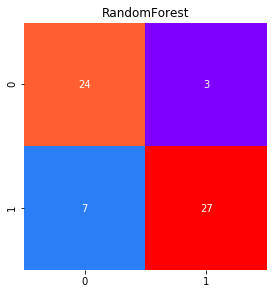

```python
#RandomForest
rdf_c=RandomForestClassifier(n_estimators=10,criterion='entropy',random_state=0)
rdf_c.fit(X_train,y_train)
rdf_pred=rdf_c.predict(X_test)
rdf_cm=confusion_matrix(y_test,rdf_pred)
rdf_ac=accuracy_score(rdf_pred,y_test)

plt.figure(figsize=(20,10))
plt.subplot(2,4,4)
plt.title("RandomForest")
sns.heatmap(rdf_cm,annot=True,cmap="rainbow",fmt="d",cbar=False)
```

#### Decision Tree

The Decision tree fabricates relapse or order models as a tree structure. It separates a dataset into littler and littler subsets while simultaneously a related choice tree is steadily created. The conclusive outcome is a tree with choice hubs and leaf hubs. It can deal with both clear cut and numerical information.

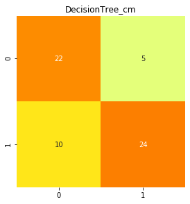

```python
# DecisionTree Classifier
dtree_c=DecisionTreeClassifier(criterion='entropy',random_state=0)
dtree_c.fit(X_train,y_train)
dtree_pred=dtree_c.predict(X_test)
dtree_cm=confusion_matrix(y_test,dtree_pred)
dtree_ac=accuracy_score(dtree_pred,y_test)

plt.figure(figsize=(20,10))
plt.subplot(2,4,6)
plt.title("DecisionTree_cm")
sns.heatmap(dtree_cm,annot=True,cmap="Wistia",fmt="d",cbar=False)
```

#### KNN Classification

The KNN regression accepts that comparable things exist in nearness. At the end of the day, comparative things are close to one another. It catches the possibility of similitude (here and there called separation, vicinity, or closeness) with some science we may have learned in our adolescence—figuring the separation between focuses on a diagram.

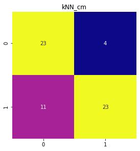

```python
#KNN
knn=KNeighborsClassifier(n_neighbors=2)
knn.fit(X_train,y_train)
knn_pred=knn.predict(X_test)
knn_cm=confusion_matrix(y_test,knn_pred)
knn_ac=accuracy_score(knn_pred,y_test)

plt.figure(figsize=(20,10))
plt.subplot(2,4,7)
plt.title("kNN_cm")
sns.heatmap(knn_cm,annot=True,cmap="plasma",fmt="d",cbar=False)
plt.show()
```

#### Model Accuracy

Machine learning version accuracy is the size used to decide which version is high-quality at identifying relationships and styles between variables in a dataset based totally at the enter, or schooling, statistics. The better a model can generalize to ‘unseen’ statistics, the better predictions and insights it could produce, which in flip supply extra business price.

```python
print('LogisticRegression_accuracy:\t',lr_ac)
print('RandomForest_accuracy:\t\t',rdf_ac)
print('DecisionTree_accuracy:\t\t',dtree_ac)
print('KNN_accuracy:\t\t\t',knn_ac)
print('BayesClassifier_accuracy:\t',bayes_ac)
```

```
LogisticRegression_accuracy:	 0.8524590163934426
RandomForest_accuracy:		 0.8360655737704918
DecisionTree_accuracy:		 0.7540983606557377
KNN_accuracy:			 0.7540983606557377
BayesClassifier_accuracy:	 0.8852459016393442
```

From the above results we can see that Naive_Bayes Classifier algorithm gives best accuracy of 88.5% as compared to other machine learning algorithm.

#### Plotting Precision Score and ROC Curve

ROC Curves summarize the alternate-off among the actual effective charge and false tremendous price for a predictive model the usage of different possibility thresholds. ROC curves are suitable while the observations are balanced between every magnificence, whereas precision-consider curves are suitable for imbalanced datasets.

```python
def plotting(true,pred):
    fig,ax=plt.subplots(1,2,figsize=(10,5))
    precision,recall,threshold = precision_recall_curve(true,pred[:,1])
    ax[0].plot(recall,precision,'g--')
    ax[0].set_xlabel('Recall')
    ax[0].set_ylabel('Precision')
    ax[0].set_title("Average Precision Score : {}".format(average_precision_score(true,pred[:,1])))
    fpr,tpr,threshold = roc_curve(true,pred[:,1])
    ax[1].plot(fpr,tpr)
    ax[1].set_title("AUC Score is: {}".format(auc(fpr,tpr)))
    ax[1].plot([0,1],[0,1],'k--')
    ax[1].set_xlabel('False Positive Rate')
    ax[1].set_ylabel('True Positive Rate')
```

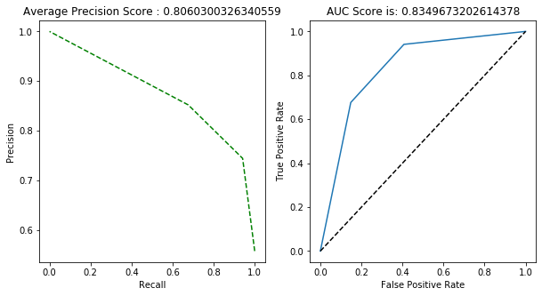

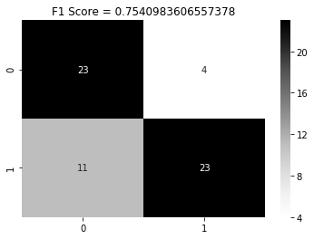

```python
#KNN F1 Score
plt.figure()

plotting(y_test,knn.predict_proba(X_test))


fig=plt.figure()
sns.heatmap(confusion_matrix(y_test,knn.predict(X_test)), annot= True, cmap='Greys')

k_f1 = f1_score(y_test,knn.predict(X_test))
plt.title('F1 Score = {}'.format(k_f1))
plt.show()
```

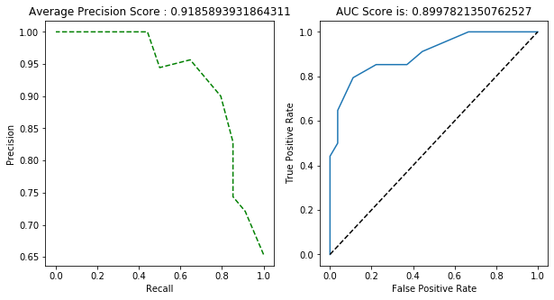

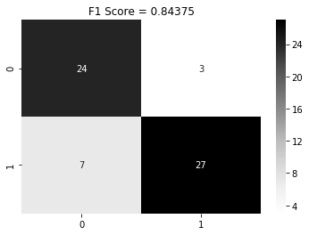

```python
# Random Forest F1 Score
plt.figure()
plotting(y_test,rdf_c.predict_proba(X_test))

fig=plt.figure()
sns.heatmap(confusion_matrix(y_test,rdf_c.predict(X_test)), annot= True, cmap='Greys')

rf_f1 = f1_score(y_test,rdf_c.predict(X_test))
plt.title('F1 Score = {}'.format(rf_f1))
plt.show()
```

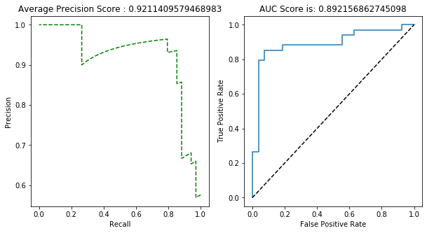

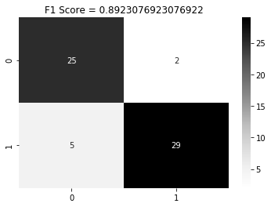

```python
#Bayes Classfication
plt.figure()
plotting(y_test,gaussian.predict_proba(X_test))

fig=plt.figure()
sns.heatmap(confusion_matrix(y_test,gaussian.predict(X_test)), annot= True, cmap='Greys')

Ga_f1 = f1_score(y_test,gaussian.predict(X_test))
plt.title('F1 Score = {}'.format(Ga_f1))
plt.show()
```

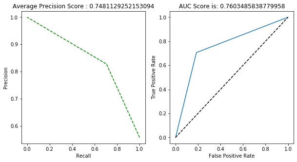

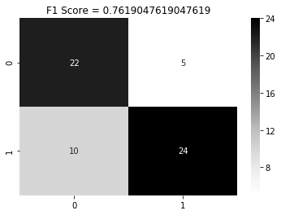

```python
# Decsions tree
plt.figure()
plotting(y_test,dtree_c.predict_proba(X_test))

fig=plt.figure()
sns.heatmap(confusion_matrix(y_test,dtree_c.predict(X_test)), annot= True, cmap='Greys')

dt_f1 = f1_score(y_test,dtree_c.predict(X_test))
plt.title('F1 Score = {}'.format(dt_f1))
plt.show()
```

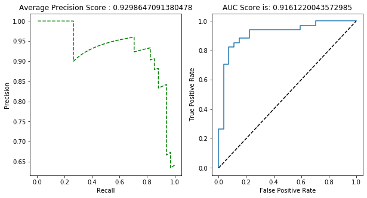

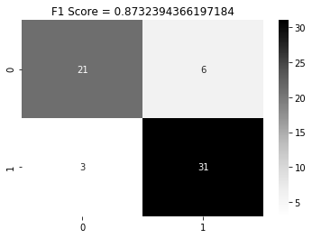

```python
#Logistic Regression

plt.figure()
plotting(y_test,lr_c.predict_proba(X_test))

fig=plt.figure()
sns.heatmap(confusion_matrix(y_test,lr_c.predict(X_test)), annot= True, cmap='Greys')

l_f1 = f1_score(y_test,lr_c.predict(X_test))
plt.title('F1 Score = {}'.format(l_f1))
plt.show()
```

#### Results and Conclusions:

##### Comparison of Model Accuracy with respect to the graph

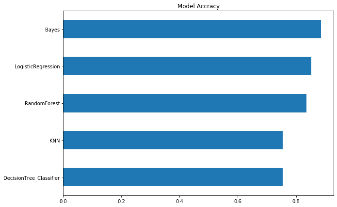

```python
model_accuracy = pd.Series(data=[lr_ac,bayes_ac,rdf_ac,dtree_ac,knn_ac],
                index=['LogisticRegression','Bayes',
                                      'RandomForest','DecisionTree_Classifier','KNN'])
fig= plt.figure(figsize=(10,7))
model_accuracy.sort_values().plot.barh()
plt.title('Model Accracy')
```

From the above graph we can see that accuracy of Bayes and Logistic regression are doing better than other ML algorithms.

In any case, for Classification task ACCURACY isn't significant. Rather than exactness model ought to be made a decision on premise of AUC (Area under Curve), ROC CURVE, High Precision and High Recall esteems. F1 score likewise assume imporant job which is equivalents to 2/(1/exactness + 1/Recall) score

[figure not shown]

```python
model_f1_score = pd.Series(data=[k_f1, Ga_f1, rf_f1, l_f1, dt_f1],
                           index=['KNN', 'Random Forest','Bayes Classfier','Logistic Regression', 'Decision Tree'])
fig= plt.figure(figsize=(9,3))
model_f1_score.sort_values().plot.barh()
plt.title('Model F1 Score Comparison')
```

It is providing 92% of precision level.